# Trabalho 2 – Regressão para dados de contagem (RS)

# 3 Análise Exploratória

## 3.1 Distribuição da Variável Resposta (Y)

Visualizamos a distribuição da contagem de óbitos (`obts`) para identificar a assimetria característica de dados de contagem e a presença de *outliers*.

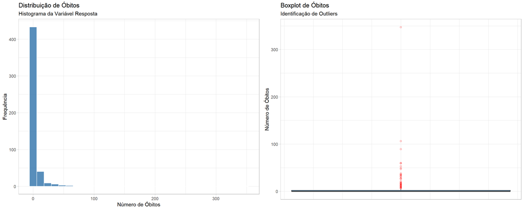

```r
# 1. Histograma da Contagem Absoluta
p1 <- ggplot(df, aes(x = obts)) +
  geom_histogram(bins = 30, fill = "steelblue", color = "white", alpha = 0.9) +
  labs(title = "Distribuição de Óbitos",
       subtitle = "Histograma da Variável Resposta",
       x = "Número de Óbitos", y = "Frequência") +
  theme_light()

# 2. Boxplot da Contagem
p2 <- ggplot(df, aes(y = obts)) +
  geom_boxplot(fill = "steelblue", outlier.colour = "red", outlier.shape = 1, alpha = 0.9) +
  labs(title = "Boxplot de Óbitos",
       subtitle = "Identificação de Outliers",
       y = "Número de Óbitos", x = "") +
  theme_light() +
  theme(axis.text.x = element_blank(), axis.ticks.x = element_blank())

grid.arrange(p1, p2, ncol = 2)
```

## 3.2 Correlação entre Variáveis (Multicolinearidade)

Verificamos a estrutura de correlação entre todas as variáveis numéricas disponíveis. O objetivo é identificar redundâncias que possam causar instabilidade no modelo (Multicolinearidade).

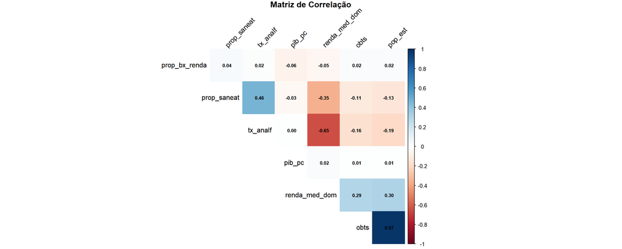

```r
# Selecionar variáveis numéricas para correlação
df_cor <- df %>%
  dplyr::select(obts, pop_est, prop_saneat, pib_pc, prop_bx_renda, renda_med_dom, tx_analf) %>%
  cor(use = "complete.obs")

# Plotar Matriz
corrplot(df_cor,
         method = "color", type = "upper", order = "hclust",
         addCoef.col = "black", tl.col = "black", tl.srt = 45,
         number.cex = 0.7, diag = FALSE,
         title = "Matriz de Correlação", mar = c(0,0,1,0))
```

## 3.3 Relação Individual: Preditores vs Taxa de Mortalidade

Visualizamos como cada variável explicativa se relaciona com a **taxa de mortalidade** (por 100k habitantes). Utilizamos a taxa no eixo Y para remover o efeito de tamanho populacional e identificar o risco real. As linhas vermelhas (suavização LOESS) ajudam a identificar tendências não-lineares.

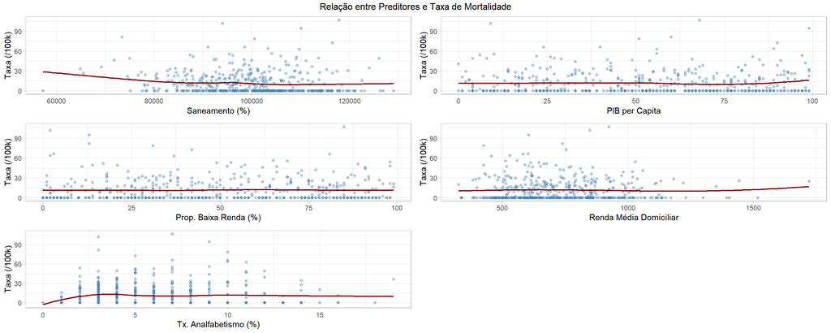

```r
# Função auxiliar para plotagem uniforme
plot_dispersao <- function(var_x, label_x) {
  ggplot(df, aes(x = {{var_x}}, y = taxa_100k)) +
    geom_point(alpha = 0.4, color = "steelblue") +
    geom_smooth(method = "loess", color = "darkred", size = 0.8, se = FALSE) +
    labs(x = label_x, y = "Taxa (/100k)") +
    theme_light()
}

# Gerar plots
g1 <- plot_dispersao(prop_saneat, "Saneamento (%)")
g2 <- plot_dispersao(pib_pc, "PIB per Capita")
g3 <- plot_dispersao(prop_bx_renda, "Prop. Baixa Renda (%)")
g4 <- plot_dispersao(renda_med_dom, "Renda Média Domiciliar")
g5 <- plot_dispersao(tx_analf, "Tx. Analfabetismo (%)")

# Exibição conjunta
grid.arrange(g1, g2, g3, g4, g5, ncol = 2,
             top = "Relação entre Preditores e Taxa de Mortalidade")
```

# 4 Ajuste de Modelos

Para modelar a taxa de óbitos, iniciamos com o modelo de referência Poisson, utilizando o logaritmo da população (`log_pop`) como offset para controlar a exposição.

## 4.1 Modelo 1: Poisson (Baseline)

```r
# Ajuste do modelo Poisson com as covariáveis socioeconômicas e saneamento
ajuste_pois <- glm(obts ~ tx_analf + prop_saneat + prop_bx_renda + pib_pc,
                   family = poisson,
                   offset = log_pop,
                   data = df)

summary(ajuste_pois)
```

```
##
## Call:
## glm(formula = obts ~ tx_analf + prop_saneat + prop_bx_renda +
##     pib_pc, family = poisson, data = df, offset = log_pop)
##
## Coefficients:
##                 Estimate Std. Error z value Pr(>|z|)
## (Intercept)   -8.021e+00  2.688e-01 -29.845  < 2e-16 ***
## tx_analf      -4.472e-02  1.122e-02  -3.987 6.68e-05 ***
## prop_saneat   -5.510e-06  2.983e-06  -1.847   0.0647 .
## prop_bx_renda  7.661e-04  8.550e-04   0.896   0.3703
## pib_pc         4.108e-04  8.005e-04   0.513   0.6078
## ---
## Signif. codes:  0 '***' 0.001 '**' 0.01 '*' 0.05 '.' 0.1 ' ' 1
##
## (Dispersion parameter for poisson family taken to be 1)
##
##     Null deviance: 939.05  on 495  degrees of freedom
## Residual deviance: 906.86  on 491  degrees of freedom
## AIC: 1642.4
##
## Number of Fisher Scoring iterations: 5
```

## 4.2 Modelo 2: Binomial Negativa

```r
# Ajuste do modelo Binomial Negativo (trata superdispersão sem inflação de zeros)
ajuste_nb <- glm.nb(obts ~ tx_analf + prop_saneat + prop_bx_renda + pib_pc + offset(log_pop),
                    data = df)

summary(ajuste_nb)
```

```
##
## Call:
## glm.nb(formula = obts ~ tx_analf + prop_saneat + prop_bx_renda +
##     pib_pc + offset(log_pop), data = df, init.theta = 2.655649804,
##     link = log)
##
## Coefficients:
##                 Estimate Std. Error z value Pr(>|z|)
## (Intercept)   -7.289e+00  5.008e-01 -14.553  < 2e-16 ***
## tx_analf       1.987e-02  1.851e-02   1.074  0.28284
## prop_saneat   -1.792e-05  5.529e-06  -3.242  0.00119 **
## prop_bx_renda -6.191e-05  1.797e-03  -0.034  0.97252
## pib_pc         3.937e-04  1.773e-03   0.222  0.82426
## ---
## Signif. codes:  0 '***' 0.001 '**' 0.01 '*' 0.05 '.' 0.1 ' ' 1
##
## (Dispersion parameter for Negative Binomial(2.6556) family taken to be 1)
##
##     Null deviance: 469.85  on 495  degrees of freedom
## Residual deviance: 457.74  on 491  degrees of freedom
## AIC: 1419.9
##
## Number of Fisher Scoring iterations: 1
##
##
##               Theta:  2.656
##           Std. Err.:  0.462
##
##  2 x log-likelihood:  -1407.880
```